# Social Media Analysis

Amar Vivek

July 13, 2017

## R Markdown

```r
#Set Working Directory and read the twitter file
setwd("C:/Users/Amar/Documents/Data Analytics/Assignment/Web and Social Media Analytics")
Wtweet.df<-read.csv("Wtweet_Final.csv",header = TRUE)

#Converting text from Factor to Char

Wtweet.df$text<-as.character(Wtweet.df$text)

# Convert char date to correct date format

Wtweet.df$created <- ymd_hms(as.character(Wtweet.df$created))
```

Cleaning the twitter data.

```r
#Cleaning the text data by removing links, tags and delimiters.

# Remove character string between < >
Wtweet.df$text <- genX(Wtweet.df$text, " <", ">")

# Create document corpus with tweet text
myCorpus<- VCorpus(VectorSource(Wtweet.df$text))

#Remove the links (URLs)
removeURL <- function(x) gsub("http[^[:space:]]*", "", x)
myCorpus <- tm_map(myCorpus, content_transformer(removeURL))

#Remove anything except the english language and space
removeNumPunct <- function(x) gsub("[^[:alpha:][:space:]]*", "", x)
myCorpus <- tm_map(myCorpus, content_transformer(removeNumPunct))

#convert to Lowercase
myCorpus <- tm_map(myCorpus, content_transformer(tolower))

#Remove Stopwords
myStopWords<- c((stopwords('english')),c("wimbledon", "see", "used", "via", "amp","keeping","manutd","mutour",
                                         "just","one","thing","after","will","can","since","the","made",
                                         "reach","feelwimbledon","cant","keep","sports","return","never",
                                         "day","get","within","make","ready","years","rt","nd"))
myCorpus<- tm_map(myCorpus,removeWords , myStopWords)

#Remove Single letter words
removeSingle <- function(x) gsub(" . ", " ", x)
myCorpus <- tm_map(myCorpus, content_transformer(removeSingle))

#Remove Extra Whitespaces
myCorpus<- tm_map(myCorpus, stripWhitespace)

#Used to replace words with the proper ones
replaceWord <- function(corpus, oldword, newword)
{
  tm_map(corpus, content_transformer(gsub), pattern=oldword, replacement=newword)
}
myCorpus<- replaceWord(myCorpus, "rafael", "nadal")
myCorpus<- replaceWord(myCorpus, "federerfederer", "federer")
myCorpus<- replaceWord(myCorpus, "rogerfederer", "federer")
myCorpus<- replaceWord(myCorpus, "andy", "murray")
myCorpus<- replaceWord(myCorpus, "williams", "venus")
myCorpus<- replaceWord(myCorpus, "konta", "johanna")
myCorpus<- replaceWord(myCorpus, "jojohanna", "johanna")
myCorpus<- replaceWord(myCorpus, "semifinals", "semifinal")

#Create term document matrix
tdm<- TermDocumentMatrix(myCorpus, control= list(wordLengths= c(1, Inf)))
tdm
```

```
## <<TermDocumentMatrix (terms: 7022, documents: 10000)>>
## Non-/sparse entries: 80945/70139055
## Sparsity           : 100%
## Maximal term length: 33
## Weighting          : term frequency (tf)
```

```r
#Create a copy of the Corpus
myCorpusCopy<-myCorpus
```

Below code shows the most frequently used words.From the term frequency chart it is evident that Murray and Federer are being talked about the most.

```r
#Find the terms used most frequently
dtm1 <- TermDocumentMatrix(myCorpus)
(freq.terms <- findFreqTerms(dtm1, lowfreq = 200))
```

```
##  [1] "asking"       "bbcsport"     "bbctennis"    "beats"
##  [5] "champion"     "cilic"        "cilicmarin"   "come"
##  [9] "court"        "defending"    "draw"         "face"
## [13] "federer"      "final"        "first"        "flying"
## [17] "gilles"       "grand"        "hes"          "hour"
## [21] "johanna"      "knocks"       "less"         "like"
## [25] "main"         "man"          "marin"        "match"
## [29] "milos"        "milosraonic"  "misses"       "moment"
## [33] "muller"       "murray"       "murraymurray" "now"
## [37] "place"        "played"       "querrey"      "raonic"
## [41] "reaches"      "roger"        "sails"        "sam"
## [45] "scottish"     "second"       "semifinal"    "set"
## [49] "sets"         "slam"         "straight"     "stuns"
## [53] "tennis"       "time"         "today"        "two"
## [57] "victory"      "win"          "won"          "year"
```

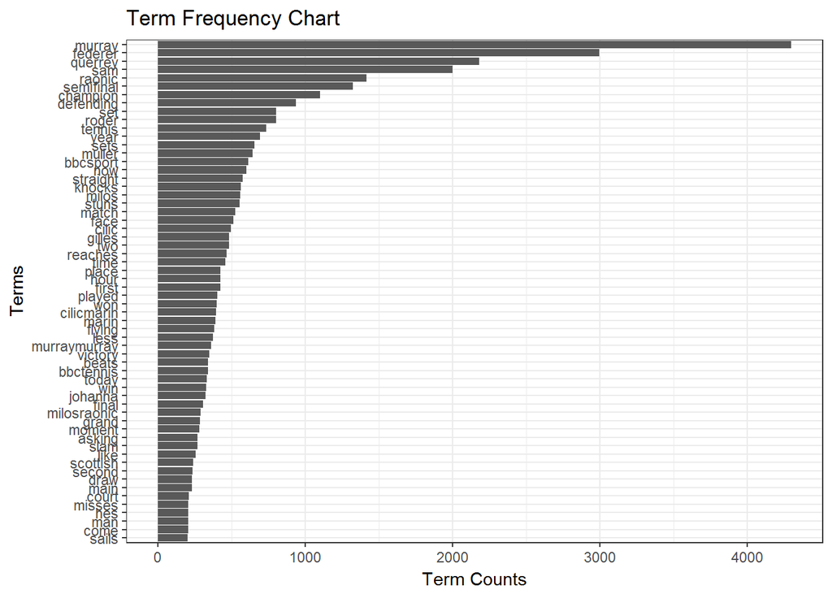

```r
term.freq <- rowSums(as.matrix(dtm1))
term.freq <- subset(term.freq, term.freq > 200)
df <- data.frame(term = names(term.freq), freq= term.freq)

#plotting the graph of frequent terms
ggplot(df, aes(reorder(term, freq),freq)) + theme_bw() + geom_bar(stat = "identity")  + coord_flip() +labs(list(title="Term Frequency Chart", x="Terms", y="Term Counts"))
```

Word Cloud:

[figure not shown]

```r
#calculate the frequency of words and sort it by frequency and setting up the Wordcloud
word.freq <-sort(rowSums(as.matrix(tdm)), decreasing= F)
pal<- brewer.pal(8, "Dark2")
wordcloud(words = names(word.freq), freq = word.freq, min.freq = 2, random.order = F, colors = pal, max.words = 80)
```

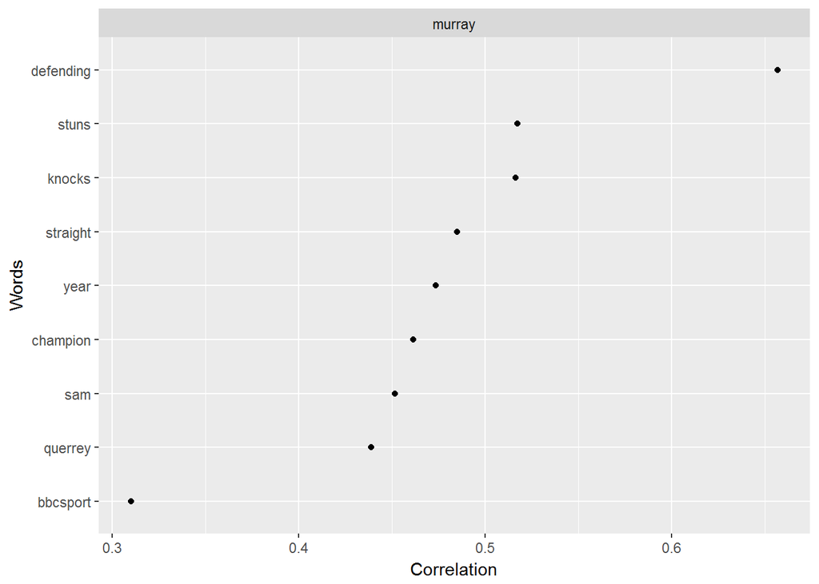

```r
# Identify and plot word correlations. For example - love
WordCorr <- apply_as_df(myCorpus[1:500], word_cor, word = "murray", r=.3)
plot(WordCorr)
```

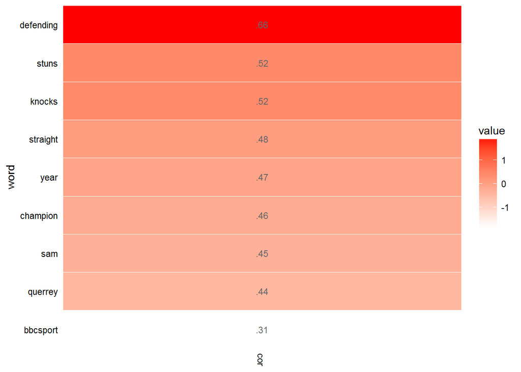

```r
qheat(vect2df(WordCorr[[1]], "word", "cor"), values=TRUE, high="red",
      digits=2, order.by ="cor", plot = FALSE) + coord_flip()
```

It is evident above that when talking about Murray people are also talking about defending. Words like champion also come up that shows that people are talking about him being the defending champion. Also there are mention of stuns which is synonymous with Querrey stunning Murray in the match.

```r
# Messages with word - murray
df <- data.frame(text=sapply(myCorpus, `[[`, "content"), stringsAsFactors=FALSE)
head(unique(df[grep("murray", df$text), ]), n=10)
```

```
##  [1] " bingobestodds bbo tipster tennis tuesday cilic djokovic federer murray win max claimgt"
##  [2] " piesportsbooze breaking murray murray scottish "
##  [3] " nicolasturgeon hard lines murraymurray youll always champion "
##  [4] " bonnegreer many reasons love murraymurraya feminist gent real murraymurraychamp "
##  [5] " winloss records last three five setters querrey murray "
##  [6] " straight year sam querrey knocks defending champion stuns murray murray "
##  [7] "writing tesresources murrays use kids teachers primary "
##  [8] " standardsport murray murray seek expert advice solve hip injury us open dankp "
##  [9] " bbcsport lets take anything away sam querreys performance bit clear murray murray discomfort "
## [10] " ctvtayos breaking sam querrey knocks defending champion murray murray "
```

Topic Modelling:

```r
dtm <- as.DocumentTermMatrix(tdm)

rowTotals <- apply(dtm , 1, sum)

NullDocs <- dtm[rowTotals==0, ]
dtm   <- dtm[rowTotals> 0, ]

if (length(NullDocs$dimnames$Docs) > 0) {
  Wtweet.df <- Wtweet.df[-as.numeric(NullDocs$dimnames$Docs),]
}

lda <- LDA(dtm, k = 5) # find 5 topic
term <- terms(lda, 7) # first 7 terms of every topic
(term <- apply(term, MARGIN = 2, paste, collapse = ", "))
```

```
##                                                     Topic 1
##    "federer, raonic, set, roger, johanna, first, bbctennis"
##                                                     Topic 2
##  "semifinal, sets, muller, federer, milos, raonic, querrey"
##                                                     Topic 3
##            "federer, now, face, place, match, querrey, sam"
##                                                     Topic 4
## "murray, sam, querrey, champion, defending, year, bbcsport"
##                                                     Topic 5
##      "tennis, murraymurray, man, win, player, like, always"
```

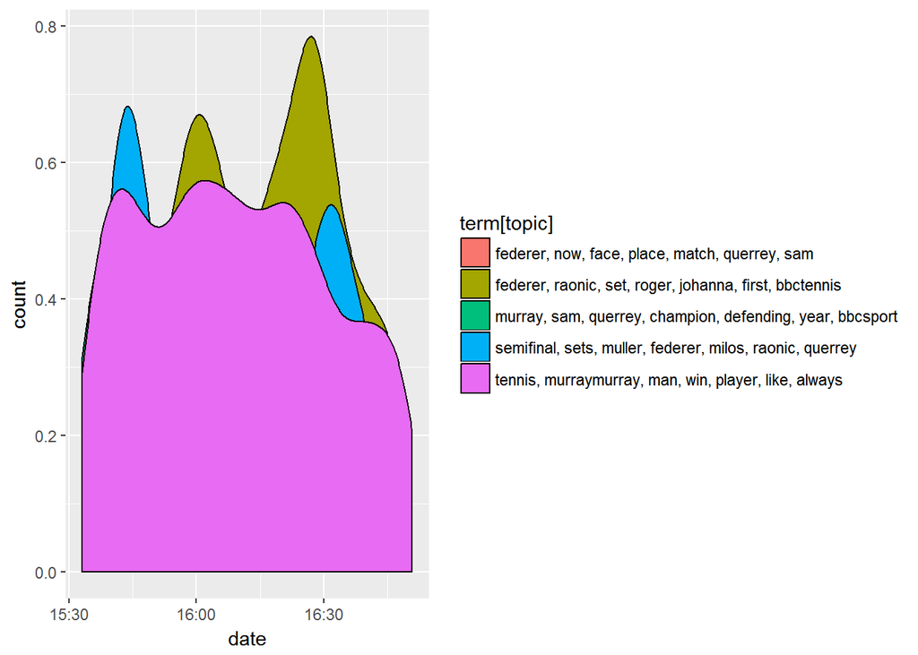

```r
topics<- topics(lda)
topics<- data.frame(date=(Wtweet.df$created), topic = topics)
qplot (date, ..count.., data=topics, geom ="density", fill= term[topic], position="stack")
```

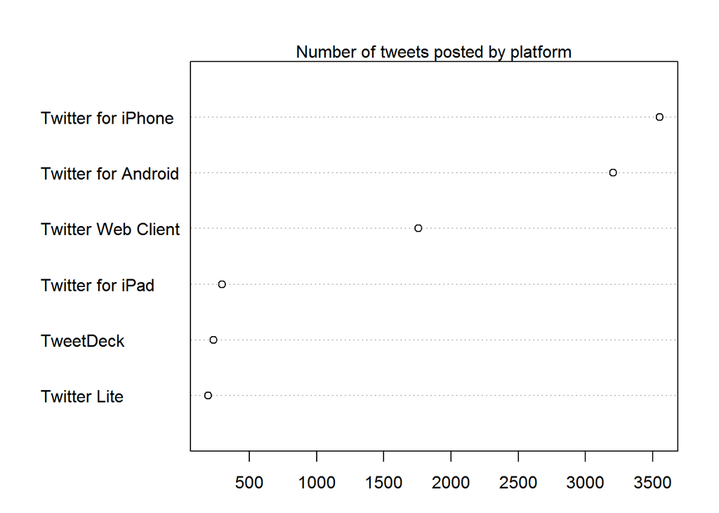

```r
par(mar = c(3, 3, 3, 2))
Wtweet.df$statusSource = substr(Wtweet.df$statusSource,
                                regexpr('>', Wtweet.df$statusSource) + 1,
                                regexpr('</a>', Wtweet.df$statusSource) - 1)
dotchart(tail(sort(table(Wtweet.df$statusSource))))
mtext('Number of tweets posted by platform')
```

Sentiment Analysis

```r
sentiments <- polarity(Wtweet.df$text)
sentiments <- data.frame(sentiments$all$polarity)

sentiments[["polarity"]] <- cut(sentiments[[ "sentiments.all.polarity"]], c(-5,0.0,5), labels = c("negative","positive"))

table(sentiments$polarity)
```

```
##
## negative positive
##     5500     4499
```

The table above shows that there are more negative connotations to the message. This might be because Murray lost and he was the defending champion.

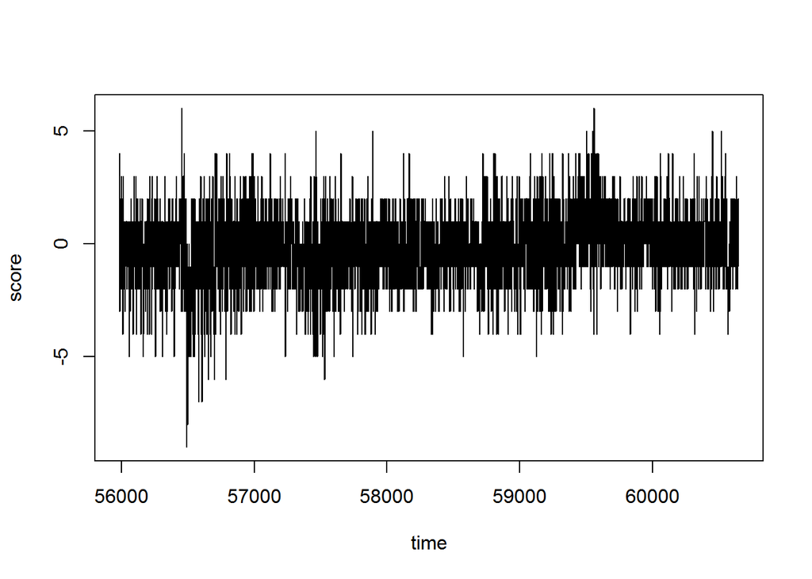

```r
#Sentiment Plot by Time

sentiments$score<- 0
sentiments$score[sentiments$polarity == "positive"]<-1
sentiments$score[sentiments$polarity == "negative"]<- -1
sentiments$time <- as.ITime(Wtweet.df$created)
result <- aggregate(score ~ time, data = sentiments, sum)
plot(result, type = "l")
```

```r
#Stream Graph for sentiment by date


Data<-data.frame(sentiments$polarity)
colnames(Data)[1] <- "polarity"
Data$Date <- as.ITime(Wtweet.df$created)
Data$text <- NULL
Data$Count <- 1

graphdata <- aggregate(Count ~ polarity + as.character.Date(Date),data=Data,FUN=length)
colnames(graphdata)[2] <- "Date"
str(graphdata)
```

```
## 'data.frame':    5971 obs. of  3 variables:
##  $ polarity: Factor w/ 2 levels "negative","positive": 2 1 1 1 2 2 1 2 1 2 ...
##  $ Date    : chr  "15:33:06" "15:33:07" "15:33:08" "15:33:09" ...
##  $ Count   : int  4 1 3 2 1 2 2 1 1 1 ...
```

```r
graphdata$Date <- as.ITime(graphdata$Date, format= "%H:%M:%S")
graphdata$Date <- as.factor((graphdata$Date))
graphdata$Count <- as.numeric(graphdata$Count)
graphdata_df <- as.data.frame(graphdata)

streamgraph(data = graphdata, key = "polarity", value = "Count", date = "Date",
            scale="continuous", offset = "silhouette", interpolate = "cardinal",
            width = "200", height = "200",interactive = TRUE) %>%
  sg_legend(TRUE, "polarity: ") %>%
  sg_colors("PuOr") %>%
  sg_axis_x(tick_interval = 1, tick_units = "Date", tick_format = "%H")
```

```
## Use 'sg_fill_*' for setting stream colors. This parameter will be removed in an upcoming release.
```

[interactive chart not shown]

**For some reason the streamgraph was not working.

Tweet Polarity

```r
# Split into retweets and original tweets
sp = split(Wtweet.df, Wtweet.df$isRetweet)
orig = sp[['FALSE']]

pol =
  lapply(orig$text, function(txt) {
    # strip sentence enders so each tweet is analyzed as a sentence,
    # and +'s which muck up regex
    gsub('(\\.|!|\\?)\\s+|(\\++)', ' ', txt) %>%
      # strip URLs
      gsub(' http[^[:blank:]]+', '', .) %>%
      # calculate polarity
      polarity()
  })
orig$emotionalValence = sapply(pol, function(x) x$all$polarity)

# As reality check, what are the most and least positive tweets
orig$text[which.max(orig$emotionalValence)]
```

```
## [1] "41-13 is really nice record Good luck Tomas!! @tomasberdych #Wimbledon https://t.co/KEG14A0PNW"
```

```r
orig$text[which.min(orig$emotionalValence)]
```

```
## [1] "People saying Murray faked his injury are the most disgusting people on earth disgusting accusation I guess he lost on purpose #Wimbledon"
```

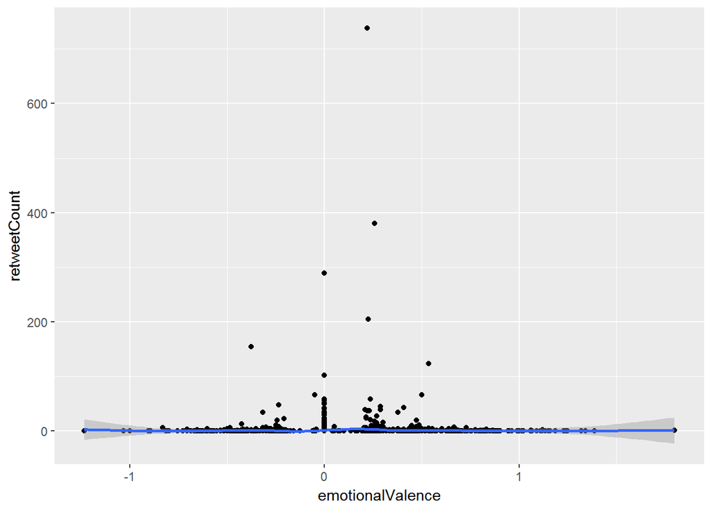

```r
# Do Happier Tweets get retweeted more

ggplot(orig, aes(x = emotionalValence, y = retweetCount)) +
  geom_point(position = 'jitter') +
  geom_smooth()
```

Emotional Content:

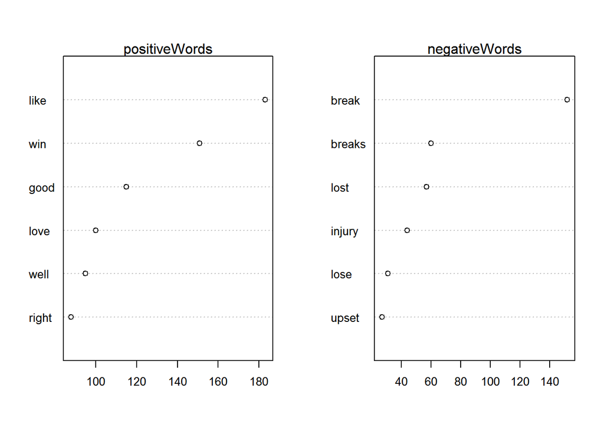

```r
#Emotional Content

polWordTables =
  sapply(pol, function(p) {
    words = c(positiveWords = paste(p[[1]]$pos.words[[1]], collapse = ' '),
              negativeWords = paste(p[[1]]$neg.words[[1]], collapse = ' '))
    gsub('-', '', words)  # Get rid of nothing found's "-"
  }) %>%
  apply(1, paste, collapse = ' ') %>%
  stripWhitespace() %>%
  strsplit(' ') %>%
  sapply(table)

par(mfrow = c(1, 2))
invisible(
  lapply(1:2, function(i) {
    dotchart(tail(sort(polWordTables[[i]])), cex = .8)
    mtext(names(polWordTables)[i])
  }))
```

Above table shows the content of what was tweeted, parsed by the emotional valence of the tweet.

Emotionally Associated Non-Associated words

[figure not shown]

```r
#Emotionally Associated Non-Emotional Words

polSplit = split(orig, sign(orig$emotionalValence))
polText = sapply(polSplit, function(df) {
  paste(tolower(df$text), collapse = ' ') %>%
    gsub(' (http|@)[^[:blank:]]+', '', .) %>%
    gsub('[[:punct:]]', '', .)
}) %>%
  structure(names = c('negative', 'neutral', 'positive'))

# remove emotive words
polText['negative'] = removeWords(polText['negative'], names(polWordTables$negativeWords))
polText['positive'] = removeWords(polText['positive'], names(polWordTables$positiveWords))

# Make a corpus by valence and a wordcloud from it
corp = VCorpus(VectorSource(polText))
corp<- tm_map(corp,removeWords , myStopWords)
col3 = RColorBrewer::brewer.pal(3, 'Paired') # Define some pretty colors, mostly for later
wordcloud::comparison.cloud(as.matrix(TermDocumentMatrix(corp)),
                            max.words = 100, min.freq = 2, random.order=FALSE,
                            rot.per = 0, colors = col3, vfont = c("sans serif", "plain"))
```

Classified tweets by their emotionalValence score and removed the words that score on emotionally valence, to sort the content that was being talked about in emotionally different ways. 1- Negative 2- Neutral 3- Positive